# DS202W - W10 Summative

Author

Candidate Number - 48372

### Preparation work & Loading modules

```python
import pandas as pd
import plotnine as plt
import numpy as np


from sklearn.linear_model import LinearRegression, Ridge, LogisticRegression, LogisticRegressionCV
from sklearn.metrics import mean_squared_error, r2_score, accuracy_score, classification_report, confusion_matrix, roc_auc_score, f1_score
from sklearn.preprocessing import PolynomialFeatures, StandardScaler
from sklearn.model_selection import GridSearchCV, KFold, TimeSeriesSplit
from sklearn.feature_selection import SelectKBest, f_classif
from sklearn.pipeline import Pipeline

from datetime import datetime
from dateutil.relativedelta import relativedelta
```

### Part 1

### Part 1-1: Read Files

```python
yuan = pd.read_stata("./yuan_inflation_data.dta")

# observe the data structure with the first 10 rows
yuan.head()
```

|  | year | emperor | emperorname | disaster | nomgrants | external | unification | rebellion | nominal | totalwar | pop | cpi |
| --- | --- | --- | --- | --- | --- | --- | --- | --- | --- | --- | --- | --- |
| 0 | 1260 | 1 | shizu | 1 | 120755 | 0 | 1 | 2 | 73352 | 3 | 7092495.0 | 1.000000 |
| 1 | 1261 | 1 | shizu | 1 | 121713 | 0 | 1 | 1 | 39139 | 2 | 7092495.0 | 1.036895 |
| 2 | 1262 | 1 | shizu | 15 | 121765 | 1 | 5 | 1 | 80000 | 7 | 7380730.0 | 1.073790 |
| 3 | 1263 | 1 | shizu | 12 | 127751 | 0 | 1 | 0 | 74000 | 1 | 7895550.0 | 1.110685 |
| 4 | 1264 | 1 | shizu | 10 | 121095 | 0 | 1 | 0 | 89208 | 1 | 7940975.0 | 1.147580 |

### Part 1-2a:

#### Top 10 years with highest number of total wars

```python
Top10_wars = yuan.nlargest(10, 'totalwar')[['year', 'totalwar']]
print(f"Top 10 YEARS with highest war numbers are: {Top10_wars}")
```

```
Top 10 YEARS with highest war numbers are:     year  totalwar
92  1352        40
15  1275        30
95  1355        26
68  1328        17
65  1325        12
67  1327        11
71  1331        11
93  1353        11
17  1277        10
63  1323        10
```

#### Top 10 years with highest nominal money issues

##### I am still using **nlargest** instead of **nsmallest** because the column “nominal” means nominal money issues according to its README file.

```python
Top10_money = yuan.nlargest(10, 'nominal')[['year', 'nominal']]
print(f"Top 10 YEARS with highest nominal money issues are: {Top10_money}")
```

```
Top 10 YEARS with highest nominal money issues are:     year   nominal
95  1355  49500000
50  1310  36259200
94  1354  34500000
92  1352  19500000
93  1353  19500000
52  1312  11211680
51  1311  10900000
53  1313  10200000
54  1314  10100000
42  1302  10000000
```

#### Overlap years - War & Money

```python
overlap_war_money = pd.merge(Top10_wars, Top10_money, on='year')
print(f"overlapping years of highest total war numbers and nominal money issues are: {overlap_war_money}")
```

```
overlapping years of highest total war numbers and nominal money issues are:    year  totalwar   nominal
0  1352        40  19500000
1  1355        26  49500000
2  1353        11  19500000
```

#### **Comment-Part 1-2a**: In this section, I identify the top 10 years with the highest number of wars and the top 10 years with the highest nominal money issues.

#### There are **3** years: **1352, 1355, 1353** appear in both lists. In other words, they are the **“overlap years”**

### Part 1-2b:

#### Top 10 highest number of disasters

```python
Top10_disaster = yuan.nlargest(10, 'disaster')[['year', 'disaster']]
print(f"Top 10 YEARS with highest number of disasters are: {Top10_disaster}")
```

```
Top 10 YEARS with highest number of disasters are:     year  disaster
64  1324        94
69  1329        92
68  1328        69
66  1326        68
65  1325        65
36  1296        64
38  1298        60
45  1305        49
61  1321        49
70  1330        48
```

#### Overlap years - Disaster & Money

```python
overlap_disaster_money = pd.merge(Top10_disaster, Top10_money, on='year')
print(f"overlapping years of highest disasters and nominal money issues are: {overlap_disaster_money}")
```

```
overlapping years of highest disasters and nominal money issues are: Empty DataFrame
Columns: [year, disaster, nominal]
Index: []
```

#### **Comment-Part 1-2b**: In this section, I identify the top 10 years with the highest number of disasters.

#### There are **no overlap years** between the top 10 years of highest number of disasters & the top 10 years with the highest nominal money issues.

### Part 1-2c:

#### Code Section 1 - Explain

##### In this section, I converts my **yuan** data into a **long format**. This is because I am plotting 4 variables in 1 diagram, and changing format enables me using 4 **colours** to distinguish 4 columns.

#### Code Section 2 - Explain

##### In this section, I use ggplot to plot the change of 4 variables across time. I did not change the default theme and colour for lines, as I am satisfied with them.

##### However, I noticed that these four variables have significantly different scales. For instance, **nominal** generally has values in the millions (7 digits), while **totalwar** generally are in 2-digit values. If I plot them directly on the same graph, the trend of wars will be barely visible due to the large differences in scale.

##### Thus, I apply a **log10 transformation** to the y-axis. This transformation compresses large values, but leave trend visible.

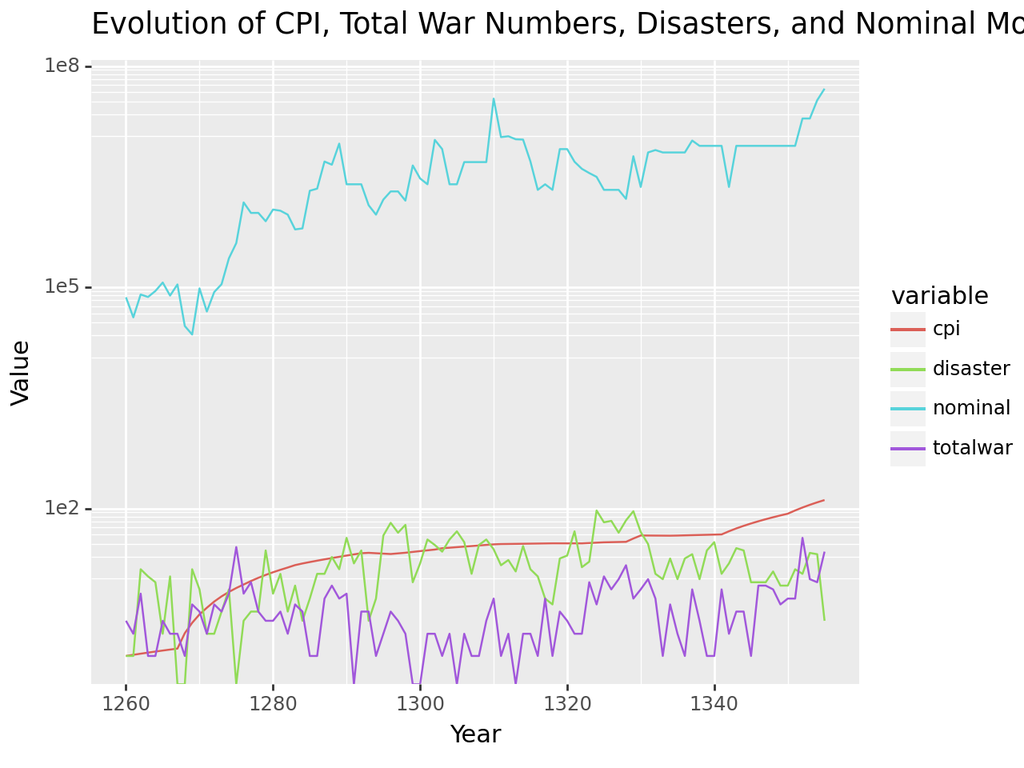

```python
# Code Section 1
yuan_long = yuan.melt(
    id_vars=['year'],
    value_vars=['cpi', 'totalwar', 'disaster', 'nominal'],
    var_name='variable',
    value_name='value'
)

# Code Section 2
(
    plt.ggplot(yuan_long, plt.aes(x='year', y='value', color='variable'))
     + plt.geom_line()
     + plt.labs(
         title='Evolution of CPI, Total War Numbers, Disasters, and Nominal Money Issues',
         x='Year',
         y='Value'
       )
     + plt.scale_y_continuous(trans='log10')
)
```

#### Another index that witnessed **a relatively significant increase is the CPI**, which has a smooth upward-sloping line throughout 100 years. CPI is an index representing the **inflation situation**. Combining the fact of the both increase in CPI and nominal money issues, one hypothesis is that the rapid expansion of money issuance may have contributed to inflationary pressures in the Yuan Dynasty.

#### In contrast, statistics for **disaster** and **total war** did not change dramatically, but were rather volatile during the 100 years. This data practically makes sense because it is unusual for wars and natural disasters to increase a lot.

### Part 2

### Part 2-1:

#### Create training and test sets:

##### As there is no statement which variables I should use for variables, and considering this is just the first Model, I will include all variables apart from “cpi” (my target), “emperorname” (varchar), and “year”(We already know the correlation between cpi and year is extremely significant from the diagram Part 1-2c. In this section, we are more interested in finding hidden correlations between “cpi” and other variables.)

```python
yuan_train = yuan[yuan['year'] < 1327]
yuan_test = yuan[yuan['year'] >= 1327]

features = [_ for _ in yuan.columns if _ not in ['cpi', 'emperorname', 'year']]
target = 'cpi'                                  # we predict cpi

X_train = yuan_train[features]                  # Capitalized X to represent it's an input
y_train = yuan_train[target]                    # Lowercase y to represent it's an outcome
X_test = yuan_test[features]
y_test = yuan_test[target]
```

#### Generate Baseline Model & Metric

```python
baseline_model = LinearRegression()
baseline_model.fit(X_train, y_train)            # ONLY use train data

y_train_pred = baseline_model.predict(X_train)
y_test_pred  = baseline_model.predict(X_test)

rmse_train = np.sqrt(mean_squared_error(y_train, y_train_pred))
rmse_test  = np.sqrt(mean_squared_error(y_test, y_test_pred))
r2_train   = r2_score(y_train, y_train_pred)
r2_test    = r2_score(y_test, y_test_pred)

print("Baseline Model Performance on training and test:")
print("Training RMSE: {:.3f}".format(rmse_train))
print("Training R²: {:.3f}".format(r2_train))
print("Test RMSE: {:.3f}".format(rmse_test))
print("Test R²: {:.3f}".format(r2_test))
```

```
Baseline Model Performance on training and test:
Training RMSE: 1.355
Training R²: 0.987
Test RMSE: 28.078
Test R²: -0.090
```

#### **Comment-Part 2-1-Baseline Model**: The baseline model’s performance on traning has a 1.355 RMSE(root mean squared error), and a 0.987 R-squared value. This combo of value is quite satisfactory, given the fact that I have included all variables.

#### However, this value only means the model performs well on the training data, but if we look at its performance in the test data, the RMSE is 28.078, with a -0.090 R-squared value. This combo of value suggest this model **performs EXTREMELY badly** on the **test data**. For the R-sqaured value, we have formula 1-SSres/SStot, and a negative value means my model performs so bad that **even just using the mean of the dependent variable (the “cpi”) can get a better prediction** than my model.

#### I have some initial guesses for this huge gap in performance between train and test though. I think the major issue is I include **too many variables** in the model, where many of them are just **noises** instead of meaningful data. For instance, the column emperor shows this year is ruled by the x-th number of emperor, but my baseline model would treat it as numerical features (1,2,3…), which misleads my model, introducing meaningless patterns. So the next step is either doing modifications to, or getting rid of these noises.

#### Residual Plot

##### Explain - section 1: In the section 1, I am calculating the residuals for train data and test data, by using the formula: acutual statsitic - predict statistic, then assign a group to each one, to distinguish whether it is train or test. After that, I pd.concat two dfs into a single one to facilitate my plotting.

##### P.S. I have considered whether using abs() to modify values to positive, or use residual square instead of raw residual, but I then realized that a raw residual tells me if data is more **underpredicted or overpredicted**, so I keep raw residual.

##### Explain - section 2: In the section 2, I simply create a scatter plot to demonstrate their respective performance. For visual friendly, I set alpha as 1 and use minimal theme.

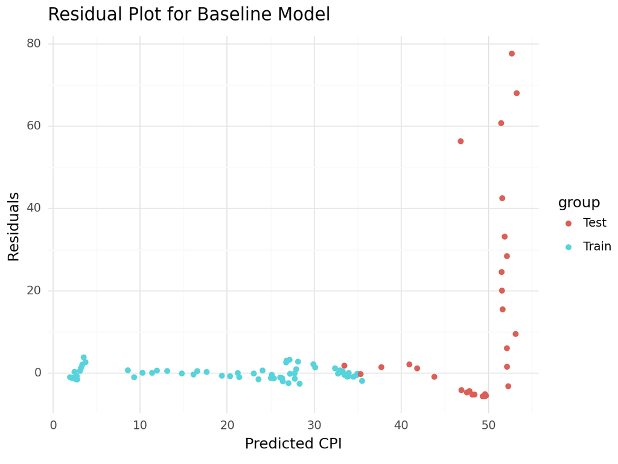

```python
# section 1
df_train = pd.DataFrame({
    'predicted': y_train_pred,
    'residual': y_train - y_train_pred,
    'group': 'Train'})

df_test = pd.DataFrame({
    'predicted': y_test_pred,
    'residual': y_test - y_test_pred,
    'group': 'Test'})

df_residuals = pd.concat([df_train, df_test], ignore_index=True)

# section 2
(
    plt.ggplot(df_residuals, plt.aes(x='predicted', y='residual', color='group')) +
    plt.geom_point(alpha=1) +
    plt.labs(title="Residual Plot for Baseline Model",
             x="Predicted CPI",
             y="Residuals") +
    plt.theme_minimal()
)
```

#### **Comment-Part 2-1-Plot**: This plot is a visual demonstration of my **Comment-Part 2-1-Baseline Model**. Residual value for most blue dots (Train) are close to 0, while red dots (Test) have much higher residual values, which some almost reach 80. This suggests my baseline model performs good on train data, but very bad on test data. There are many improvements I still need to make on this model to make it has a more decent performance, which is what I will do next.

### Part 2-2

#### Improved model

##### Explain - section 1: I have done 2 **feature engineering** work in this part. 1, I have created a new feature called **time_trend** to calculate how many years have passed since the start of Yuan Dynasty. This helps my model capture long-term trend; 2, I have also created a new column **cpi_last_year**, which contains the last year’s cpi information. For instance, the row with year 1270 contains year 1269’s cpi 2.815 as cpi_last_year. I expect this would improve model’s ability to forecast future CPI changes (our target).

##### However, because there is no cpi_last_year for the first year 1260, so I need to drop the first raw. This is done by using the dropna() function. And I rest the index after the drop.

##### Explain - section 2: This part of code is the same as Part 2-1, but unlike Part 2-1, I **remove the column “emperor”**, with the reason stated in the **Comment-Part 2-1-Baseline Model** section. I have tested the final RMSE and R-squared for both cases (remove or not remove), and the results are: **RMSE decreases from 7.555 to 6.445**, **R-squared increases from 0.921 to 0.943**. This combination of results suggest the removel improves the performance of my improved model, and justifies my decision in removing “emperor”.

##### Explain - section 3: This part is about tuning the model. I begin by creating a GridSearchCV object from the scikit-learn library. I use the singular value decomposition(svd) solver for estimating the model parameters (reasons for using svd is explained in comment section), and choose the common 5-fold cross-validation. The porformance of model is evaluated by the mean squared error (MSE), and through comparing the final alpha value, I can get the improved model.

##### Explain - section 4: This part assesses the performance of my improved model with RMSE and R-squared value. Code is similar to Part 2-1.

```python
# Section 1
yuan['time_trend'] = yuan['year'] - yuan['year'].min()

yuan['cpi_last_year'] = yuan['cpi'].shift(1)
yuan = yuan.dropna(subset=['cpi_last_year']).reset_index(drop=True)


# Section 2
yuan_train = yuan[yuan['year'] < 1327]
yuan_test  = yuan[yuan['year'] >= 1327]

target = 'cpi'
features = [col for col in yuan.columns if col not in ['cpi', 'emperor', 'emperorname', 'year']]

X_train = yuan_train[features]
y_train = yuan_train[target]
X_test  = yuan_test[features]
y_test  = yuan_test[target]


# Section 3
param_grid = {'alpha': [0.001, 0.01, 0.1, 1.0, 10.0, 100.0]}
ridge = Ridge(solver='svd')

cv = KFold(n_splits=5, shuffle=True, random_state=12345)
grid_search = GridSearchCV(ridge, param_grid, cv=cv, scoring='neg_mean_squared_error')
grid_search.fit(X_train, y_train)


print("best alpha value is:", grid_search.best_params_['alpha'])
improved_model = grid_search.best_estimator_


# Section 4
y_train_pred_improved = improved_model.predict(X_train)
y_test_pred_improved  = improved_model.predict(X_test)

rmse_train_improved = np.sqrt(mean_squared_error(y_train, y_train_pred_improved))
rmse_test_improved  = np.sqrt(mean_squared_error(y_test, y_test_pred_improved))
r2_train_improved   = r2_score(y_train, y_train_pred_improved)
r2_test_improved    = r2_score(y_test, y_test_pred_improved)

print("\nImproved Model Performance:")
print("Training RMSE: {:.3f}".format(rmse_train_improved))
print("Training R²: {:.3f}".format(r2_train_improved))
print("Test RMSE: {:.3f}".format(rmse_test_improved))
print("Test R²: {:.3f}".format(r2_test_improved))
```

```
best alpha value is: 0.001

Improved Model Performance:
Training RMSE: 0.353
Training R²: 0.999
Test RMSE: 6.445
Test R²: 0.943
```

#### **Comment-Part 2-2-Improved Model**: Compared to the baseline model, I have made 3 modifications to the baseline model: feature engineering, deleting columns, and tuning model. And the result is the **improved model performs much better in both training data and test data**, which is supported by better statistics in RMSE and R-squared. The improvement in test data is more significant, in which the RMSE decreases from 28.078 to 6.445, and the R-squared increases from -0.090 to 0.943.

#### **Comment-Part 2-2-Improved Model**: I want to talk a bit more about my choice of **svd**. At first, I noticed 2 characteristics of my yuan dataframe: 1, it is a small one, in which there are roughly only 100 rows. 2, During the time when I was still halfway in model modifications, I received many warnings about ill-conditioned matrix in my test outputs, which suggests there is a high multicollinearity present, which generally there are means many highly-correlated variables present. Thus, I choose **svd** because it is robust in treating ill-conditioned matrix, and in small dataframe.

#### Plot for Improved model

##### The code structure is similar to baseline model, so I will not duplicate explanation. The only modification is I set the scale of y-axis from -10 to 80. I did this to ensure 2 scatter plots share the same axis for both baseline model and improved model, so viewers can clearly observe the distribution of red dots (residuals for test data).

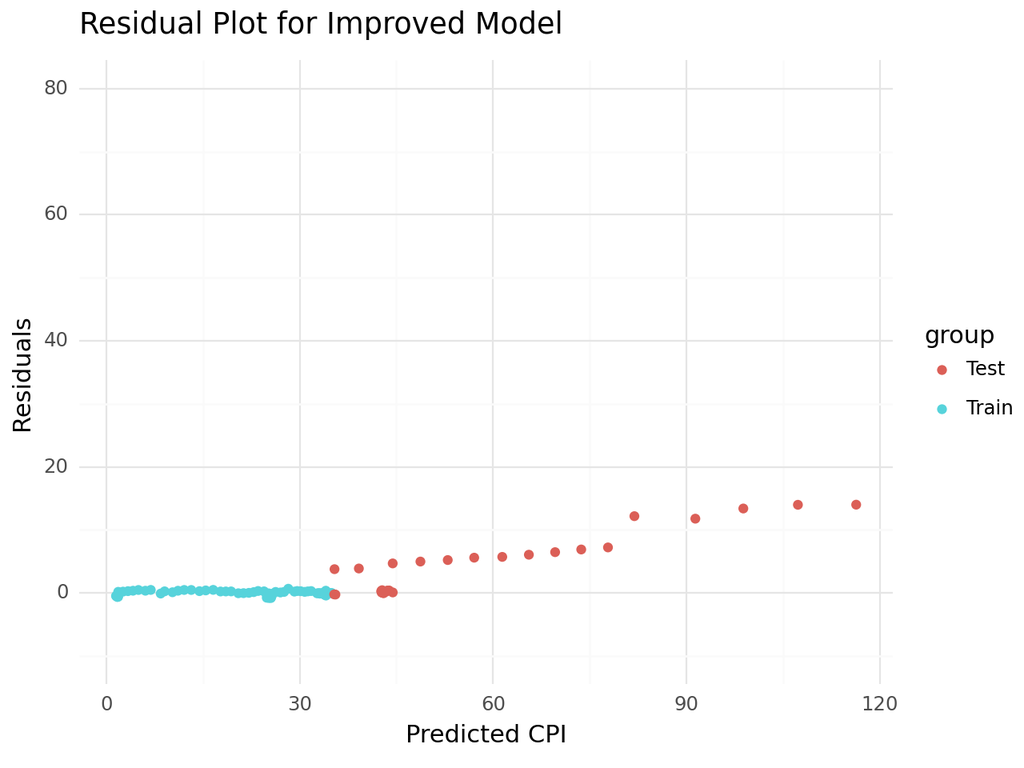

```python
df_train_improved = pd.DataFrame({
    'predicted': y_train_pred_improved,
    'residual': y_train - y_train_pred_improved,
    'group': 'Train'})

df_test_improved = pd.DataFrame({
    'predicted': y_test_pred_improved,
    'residual': y_test - y_test_pred_improved,
    'group': 'Test'})


df_residuals_improved = pd.concat([df_train_improved, df_test_improved], ignore_index=True)

(
    plt.ggplot(df_residuals_improved, plt.aes(x='predicted', y='residual', color='group')) +
    plt.geom_point(alpha=1) +
    plt.labs(title="Residual Plot for Improved Model",
             x="Predicted CPI",
             y="Residuals") +
    plt.scale_y_continuous(limits=(-10, 80)) +
    plt.theme_minimal()
)
```

#### **Comment-Part 2-2-Improved plot**: Compared to the plot for the baseline model, aggregately speaking, the residuals for the prediction of test data cpi value decrease significantly. In the diagram, red dots are distributed closer to the baseline of X-axis (the straight line where y=0). This proves my improved model performs better than baseline model in test data. For train data, the metric suggests there is also an improvement in prediction accuracy, but it is less obvious on the scatter plot.

### Part 3-1: Data Processing

##### Explain - Section 1: In this part, I am doing some basic processing to the data from BoE_interest_rates.csv and economic_indicators_interest_rate_setting.csv; In the section 1, I read 2 csv files with pandas. I am required strictly to call the dataframe of interest rates as **df**, though I really think a name like df_interest is much better. There is no naming requirement for indicators, so I call it **df_indi**.

##### Explain - Still Section 1: Next, I rename some variables. I notice there are both “**Date**” in 2 dataframes. To distinguish them, I rename the Date in df as **event_date** because these are dates when rate setting happens. For df_indi, I change many of its variables into a simplified version. I understand that creators of this csv file want to explain every variable in detail, but the too cumbersome naming method causes confusion.

##### Explain - Section 2: As required, I have assigned the indicator values to each row, which indicator values are the average of the last 3 months. This part of code is quite common, so no specific explanations are needed. However, it is worth noting that the **event_date 2025-02-06 does not have indicator values, because last month in df_indi is 2024-11**, so there is no “last 3 months” data for 2025-02-06. In this situation, I have no choice but to **remove this row**.

```python
# Section 1

df = pd.read_csv("./BoE_interest_rates.csv")
df.rename(columns={"Date": "event_date"}, inplace=True)

df_indi = pd.read_csv("./economic_indicators_interest_rate_setting.csv")
rename_mapping = {
    "Date": "date",
    "Unemployment rate (aged 16 and over, seasonally adjusted): %": "unemployment rate",
    "CPIH MONTHLY RATE 00: ALL ITEMS 2015=100": "CPIH RATE",
    "Gross Value Added - Monthly (Index 1dp) :CVM SA": "Gross Value Added",
    "Monthly average Spot exchange rate, Sterling into US$              [a]             XUMAGBD": "GBP_USD",
    "Monthly average Spot exchange rates, Sterling into Euro              [a]             XUMASER": "GBP_EUR"
}
df_indi.rename(columns=rename_mapping, inplace=True)


# Use to_datetime function to process raw string values to datetime objects is crucial for my futher processing.
df_indi['date'] = pd.to_datetime(df_indi['date'])
df['event_date'] = pd.to_datetime(df['event_date'])

# check rate setting events occur every year.
print("Number of rate settings every year is:")
print(df['event_date'].dt.year.value_counts().sort_index())




# Section 2
econ_columns = ['CCI', 'CPIH RATE', 'Gross Value Added', 'GBP_EUR', 'GBP_USD', '10-year-gilt-yield', 'unemployment rate']

for col in econ_columns:
    df[col + "_avg"] = np.nan

for idx, row in df.iterrows():
    event_date = row['event_date']
    start_date = event_date - relativedelta(months=3)

    mask = (df_indi['date'] >= start_date) & (df_indi['date'] < event_date)
    df_slice = df_indi.loc[mask]

    for col in econ_columns:
        df.loc[idx, col + "_avg"] = df_slice[col].mean()


# remove last row: event_date = 2025-02-06
df.drop(df.index[-1], inplace=True)
# Observe the final structure of df after all these operations.
df.head()
```

```
Number of rate settings every year is:
event_date
1997    5
1998    4
1999    6
2000    2
2001    7
2003    3
2004    4
2005    1
2006    2
2007    4
2008    5
2009    3
2016    1
2017    1
2018    1
2020    2
2021    1
2022    8
2023    5
2024    2
2025    1
Name: count, dtype: int64
```

|  | event_date | Rate | rate_change | CCI_avg | CPIH RATE_avg | Gross Value Added_avg | GBP_EUR_avg | GBP_USD_avg | 10-year-gilt-yield_avg | unemployment rate_avg |
| --- | --- | --- | --- | --- | --- | --- | --- | --- | --- | --- |
| 0 | 1997-05-06 | 6.25 | 1 | 102.803300 | 0.333333 | 62.866667 | 0.707600 | 0.616167 | 7.420167 | 7.200000 |
| 1 | 1997-06-06 | 6.50 | 1 | 102.885733 | 0.333333 | 63.000000 | 0.698467 | 0.611333 | 7.315967 | 7.233333 |
| 2 | 1997-07-10 | 6.75 | 1 | 102.910667 | 0.133333 | 63.033333 | 0.683067 | 0.606367 | 7.122533 | 7.200000 |
| 3 | 1997-08-07 | 7.00 | 1 | 102.891300 | 0.133333 | 63.266667 | 0.670233 | 0.610233 | 7.096267 | 7.066667 |
| 4 | 1997-11-06 | 7.25 | 1 | 102.958967 | 0.133333 | 63.933333 | 0.679933 | 0.609667 | 6.652167 | 6.600000 |

### Part 3-2: Baseline Logistic Regression Model

##### According to the requirement, 70% rows of df used for training, and 30% are used for testing.

```python
feature_cols = [col + "_avg" for col in econ_columns]
X = df[feature_cols]
y = df['rate_change']

# maintain the time order
df.sort_values('event_date', inplace=True)
X = df[feature_cols]
y = df['rate_change']


n = len(df)
split_index = int(round(n * 0.7))

# 70% for training
X_train = X.iloc[:split_index]
y_train = y.iloc[:split_index]

# 30% for testing
X_test = X.iloc[split_index:]
y_test = y.iloc[split_index:]

# Verify
print("training set size is (70%):", X_train.shape[0])
print("test set size is (30%):", X_test.shape[0])
```

```
training set size is (70%): 47
test set size is (30%): 20
```

##### When train and test data are ready, we work on designing a logistic regression model. There are multiple variables in df, so it will be a multinomial model. I also increases iteration numbers from default(100) to 200, as I receive warnings about not enough iterations.

```python
clf = LogisticRegression(multi_class='multinomial', solver='lbfgs', max_iter=200)
clf.fit(X_train, y_train)

# Predict on the test set
y_pred = clf.predict(X_test)

# Evaluate the model using accuracy and a classification report
f1 = f1_score(y_test, y_pred)
accuracy = accuracy_score(y_test, y_pred)

print("Test F1 Score:", f1)
print("Test Accuracy:", accuracy)
print("Classification Report:")
print(classification_report(y_test, y_pred))

# confusion matrix
cm = confusion_matrix(y_test, y_pred)
cm_df = pd.DataFrame(cm, index=clf.classes_, columns=clf.classes_)
print("Confusion Matrix:")
print(cm_df)
```

```
Test F1 Score: 0.10526315789473684
Test Accuracy: 0.15
Classification Report:
              precision    recall  f1-score   support

          -1       0.12      0.50      0.19         4
           1       0.33      0.06      0.11        16

    accuracy                           0.15        20
   macro avg       0.23      0.28      0.15        20
weighted avg       0.29      0.15      0.12        20

Confusion Matrix:
    -1   1
-1   2   2
 1  15   1
```

[output not shown]

##### Plotting: To better visually demonstrate the output, I have used a matrix heatmap (geom_tile) to demonstrate the differences between the model’s prediction of rate change, and the actual rate change.

##### P.S. Before the actual plotting, I need to modify my cm_df with .melt (function from pandas) to a long format. But I do not need to use it again anywhere, so I make the long format cm_df a throw away variable “_“.

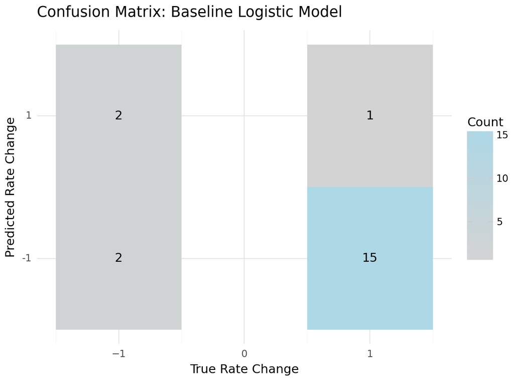

```python
_ = (
    cm_df.reset_index()
    .melt(id_vars='index', var_name='Predicted', value_name='Count')
    .rename(columns={'index': 'True'})
)

(
    plt.ggplot(_, plt.aes(x='True', y='Predicted', fill='Count')) +
    plt.geom_tile() +
    plt.geom_text(plt.aes(label='Count'), color='black') +
    plt.scale_fill_gradient(low="lightgrey", high="lightblue") +
    plt.labs(title='Confusion Matrix: Baseline Logistic Model', x='True Rate Change', y='Predicted Rate Change') +
    plt.theme_minimal()
)
```

#### **Comment-Part 3-2 Baseline Logistic Regression Model**: And among these 20 pieces, my baseline logistic model has falsely predicted 17 out of 20 changes. This could be clearly seen from either the heatmap plot or the Confusion Matrix. The baseline logistic model has predicted 15 changes are -1 (interest rate decrease), while true change is 1 (interest rate increase) — **False Negative**. predicted 2 changes are 1, while true change is -1 — **False Positive**.

#### **Comment-Part 3-2 Baseline Logistic Regression Model**: The accuracy of my baseline logistic model on test data is 0.15 (3 out of 20 successful), which is far away from being satisfactory. Looking at other statistics, the recall are respectively 0.50 and 0.06 for -1 and 1. This means my model performs moderately in capturing -1 (interest rate decrease), but performs extremely bad at capturing 1 (interest rate increase). With these combinations of recall and precision, the f1-score also looks terrible, where the statistics are very low. These statistics tell me that the baseline logistic model performs bad, and adjustments are required.

### Part3-3: Improved Logistic Regression Model

##### To start the feature engineering work, I want to observe the regression coefficients first. I set the -1 as baseline and observe the coefficient of predictors when rate_change = 1.

```python
if clf.coef_.shape[0] == 1 and len(clf.classes_) == 2:
    coef_array = np.vstack([np.zeros(clf.coef_.shape[1]), clf.coef_])
    coef_df = pd.DataFrame(coef_array, columns=feature_cols, index=clf.classes_)
else:
    coef_df = pd.DataFrame(clf.coef_, columns=feature_cols, index=clf.classes_)

print("Logistic Regression Coefficients:")
print(coef_df)
```

```
Logistic Regression Coefficients:
     CCI_avg  CPIH RATE_avg  Gross Value Added_avg  GBP_EUR_avg  GBP_USD_avg  \
-1  0.000000       0.000000               0.000000     0.000000     0.000000
 1  0.269103      -0.292562               0.113403    -0.022662    -0.272367

    10-year-gilt-yield_avg  unemployment rate_avg
-1                 0.00000               0.000000
 1                 1.46202               0.159857
```

#### **Comment-Part 3-3 Logistic Regression Coefficients**: The 2 predictors catch my attention are the “GBP_EUR_avg” and the “10-year-gilt-yield_avg”, which are respectively -0.022662 and 1.46202. This large disparity indicates that the **predictors contribute very unequally** to the model. This disparity suggests that the model relies heavily on a few key variables (e.g. 10-year-gilt-yield_avg) while others may be **adding noises**.

#### **Comment-Part 3-3 Logistic Regression Coefficients**: Thus, I will apply **L1 regularization (lasso)** in my improved model because it can drive coefficients of less informative predictors (e.g. GBP_EUR_avg) to **exact zero**. This feature selection property helps to simplify the model to focus only on the most impactful predictors, which can improve predictive accuracy.

#### Explain - Improved Logistic Regression Model

##### As I have justified in the last section, I will use **L1 regularization (Lasso)** to tune my model. However, I **can not use lbfgs** as solver anymore because it does not comply with L1. The options I have are saga and liblinear. I could use liblinear because my target is binary (1 or -1), but because I use **PolynomialFeatures (degress=2)** to capture “paired” interactions between predictors. This introduces many new features, which increasees my feature numbers, and **saga works better with large feature numbers** compared to liblinear, so I use saga as my solver.

##### There are some other points I want to discuss. 1, I have used the pipeline framework this time, because procedures for modeling process are very complicated here. Chaining procedures into a workflow can standardize operation, maintain reproducibility and avoid mistakes. 2, my C values for cross-validation are 5 distinct values from 0.001 to 10, instead of one specific number. By doing so, my model has **more freedom to choose either strong or weak regularization**, which automatically optimizes its performance. 3, I have increased the number of maximum iterations until there is no warning in the terminal. 4, divide dataset into 5 folds (n_splits=5) is a common choice that **balance between bias and variance**.

```python
pipeline_l1 = Pipeline([
    ('poly', PolynomialFeatures(degree=2, interaction_only=True, include_bias=False)),
    ('scaler', StandardScaler()),
    ('logreg_cv', LogisticRegressionCV(
        cv=TimeSeriesSplit(n_splits=5),
        penalty='l1',
        solver='saga',
        max_iter=10000,
        random_state=12345,
        Cs=[0.001,0.01,0.1,1,10]
    ))
])


pipeline_l1.fit(X_train[feature_cols], y_train)
y_pred = pipeline_l1.predict(X_test[feature_cols])


f1 = f1_score(y_test, y_pred)
acc = accuracy_score(y_test, y_pred)

print("Test F1 Score:", f1)
print("Test Accuracy:", acc)
print("Test Classification Report:")
print(classification_report(y_test, y_pred, zero_division=0))


cm = confusion_matrix(y_test, y_pred)
cm_df_improved = pd.DataFrame(cm, index=pipeline_l1.named_steps['logreg_cv'].classes_, \
columns=pipeline_l1.named_steps['logreg_cv'].classes_)
print("Improved Confusion Matrix:")
print(cm_df_improved)
```

```
Test F1 Score: 0.8888888888888888
Test Accuracy: 0.8
Test Classification Report:
              precision    recall  f1-score   support

          -1       0.00      0.00      0.00         4
           1       0.80      1.00      0.89        16

    accuracy                           0.80        20
   macro avg       0.40      0.50      0.44        20
weighted avg       0.64      0.80      0.71        20

Improved Confusion Matrix:
    -1   1
-1   0   4
 1   0  16
```

#### Plot for Improved Logistic Regression Model

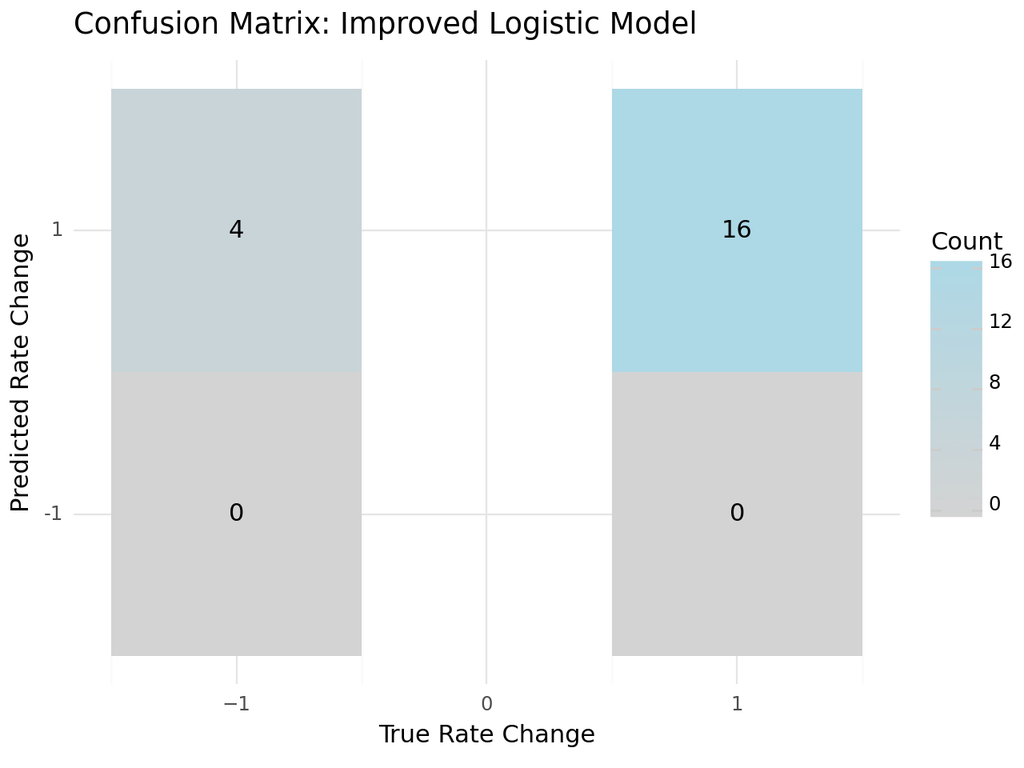

```python
_ = (
    cm_df_improved.reset_index()
    .melt(id_vars='index', var_name='Predicted', value_name='Count')
    .rename(columns={'index': 'True'})
)

(
    plt.ggplot(_, plt.aes(x='True', y='Predicted', fill='Count')) +
    plt.geom_tile() +
    plt.geom_text(plt.aes(label='Count'), color='black') +
    plt.scale_fill_gradient(low="lightgrey", high="lightblue") +
    plt.labs(title='Confusion Matrix: Improved Logistic Model', x='True Rate Change', y='Predicted Rate Change') +
    plt.theme_minimal()
)
```

#### **Comment-Part 3-3 Improved Logistic Regression Model**: I would evaluate the improved model from some statistics. My improved model has correctly predicted 16/20 rate_change. Compared to the baseline model, the Test Accuracy has increased from 0.15 to 0.8, and the f1 score has increased from 0.105 to 0.889.

#### **Comment-Part 3-3 Improved Logistic Regression Model**: I have also generated the Confusion Matrix and the plot with the same format as the baseline model for better visual demonstration. In general, all these facts have suggested that the L1 regularization (lasso approach) tunes my baseline model well, which largely improves its performance in prediction.

#### **Comment-Part 3-3 Improved Logistic Regression Model**: However, the improved model is still not perfect. One worrying problem is that it predicts every instance as 1, so none of the -1 cases are correctly identified. There are many explanations for this phenomenon. It could be overfitting or underfitting. It could be caused by multicollinearity, or by inappropriate feature engineering (in my case, L1). But at the same time, the size of the data is too small. If we divide it by 70/30, then only 20 rows are available to evaluate the performance of the model. And among these 20 rows, I only have 4 “-1” true rate changes in the test data. I cannot tell whether the fact that my improved model is predicting all -1s incorrectly is because it is a bad model, or whether it is just random error. If I had more samples of “-1”, I might be able to draw that conclusion. To do this, I may need to consider **resampling** my improved model.

#### Candidate Number: 48372